# DATA 624 Spring 2019: Homework 1

Harpreet Shoker,Jagruti Solao,Ahmed Sajjad,Chad Smith,Todd Weigel

2/4/2019

```r
library(ggplot2)
library(ggfortify)
library(forecast)
library(gridExtra)
library(fpp2)
```

### 2.3) Download some monthly Australian retail data from the book website. These represent retail sales in various categories for different Australian states, and are stored in a MS-Excel file.

#### a) You can read the data into R with the following script:

```r
retaildata <- readxl::read_excel("retail.xlsx", skip=1)
```

The second argument (skip=1) is required because the Excel sheet has two header rows.

### b) Select one of the time series as follows (but replace the column name with your own chosen column):

```r
myts <- ts(retaildata[,"A3349873A"],frequency=12, start=c(1982,4))
head(myts)
```

```
##       Apr  May  Jun  Jul  Aug  Sep
## 1982 62.4 63.1 59.6 61.9 60.7 61.2
```

### c) Explore your chosen retail time series using the following functions:

autoplot(), ggseasonplot(), ggsubseriesplot(), gglagplot(), ggAcf()

Can you spot any seasonality, cyclicity and trend? What do you learn about the series?

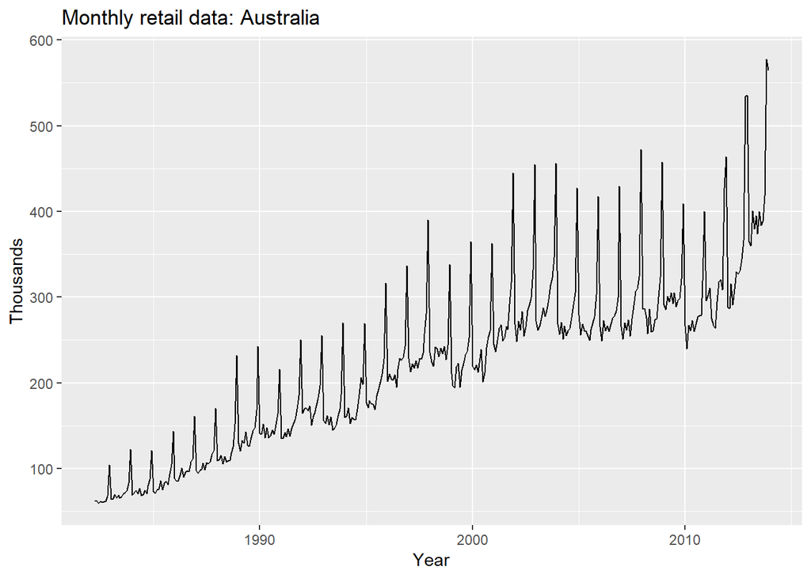

```r
autoplot(myts) +
  ggtitle("Monthly retail data: Australia") +
  xlab("Year") +
  ylab("Thousands")
```

Fig:1

Time series plot reveals following features:

1. There is continuous increment for business in retail sector data from 1982 to2012.
2. Sudden dip was observed in year 2000 and 2010 may be due to resession and slowdown of market.
3. Retail market shows dips for start of year and gradual highs towards end of it.

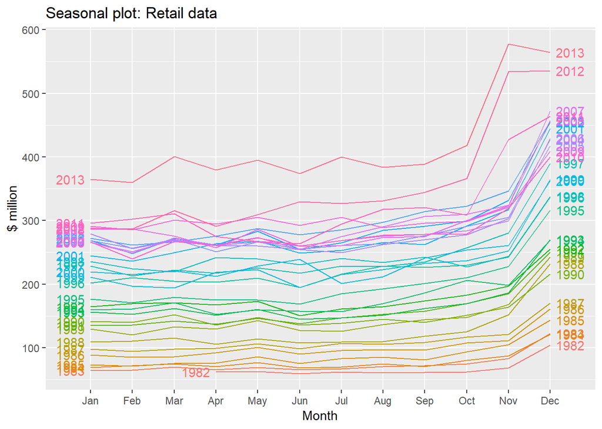

```r
ggseasonplot(myts, year.labels=TRUE, year.labels.left=TRUE) +
  ylab("$ million") +
  ggtitle("Seasonal plot: Retail data")
```

Fig: 2